# Analysis on Urban Ministries of Durham Data

Wan Zhang 730341932

11/14/2019

The datasets are provided by Urban Ministries of Durham, demonstating the imformation of clients they provided support to from 2014 by now. Unlike the date for project 1, we can only the the imfornation of clients instead of UMD services. The purpose of this project is analyzing the data with R and python to provide some visualized result from three aspects: the features of clients, analysis on the situation before the clients entry & after exit, trends of amount of clients and cases.

#### 1. How many times the clients come to UMD? How long they stay with UMD?

Firstly we show the total distribution of the frenquency (times each client comes to UMD) and period (how many days they stay with UMD each time).

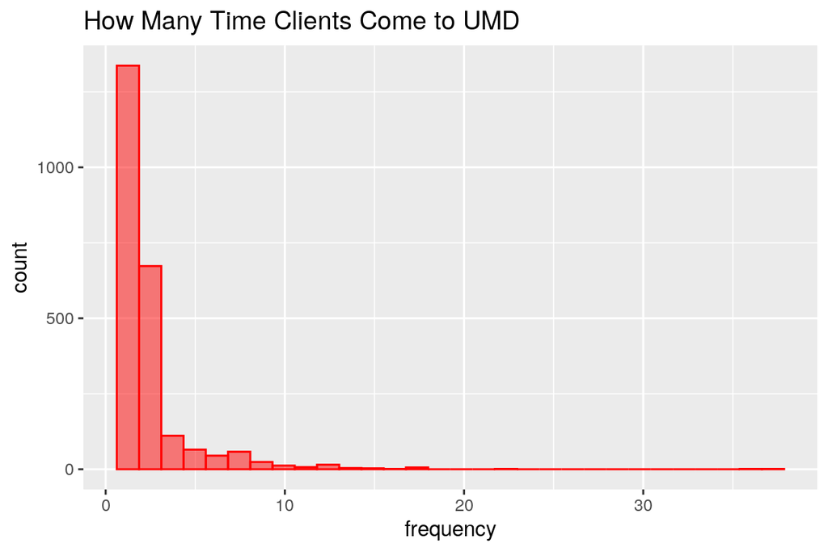

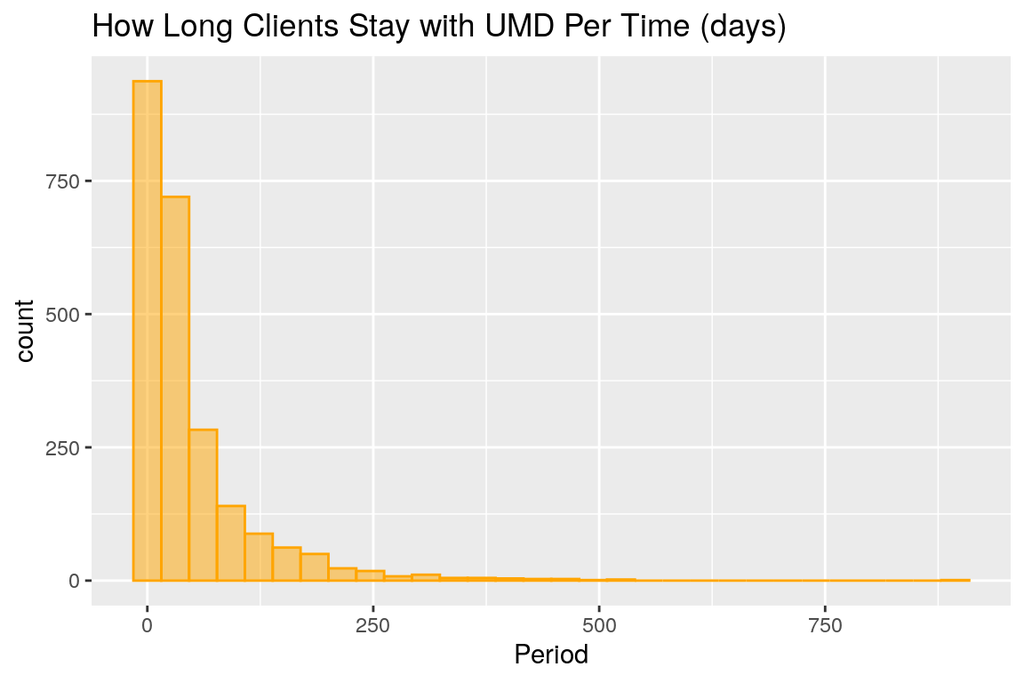

The majority of our clients will come to UMD for one or two times and stay for less than 30 days. In the following parts, I will analyze how the factors (disability, Health Insurance, Income and Age at Entry) affect frequency and period.

##### (i) Disability Status v.s. Frequency/Period

The dataset investigated the determination on 7 types of disability and I am going to show the relationship between disability status (how many kinds of disability determination) and the frequency they come to UMD/the period they stay with UMD.

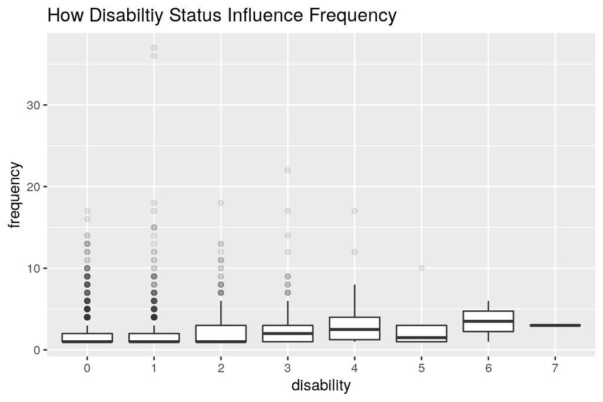

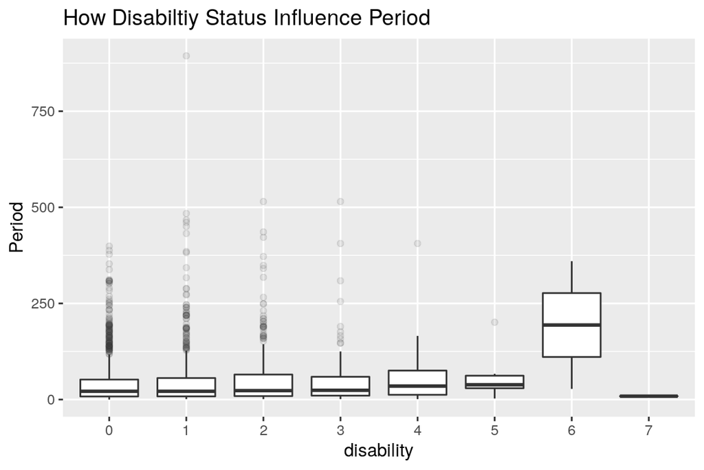

We can see that overall, clients with more types of disability tend to come to UMD more frenquently and stay for more time (not applied to 7 because there is few clients in that group).

##### (ii) Health Insurance v.s. Frequency/Period

The dataset provided information on 10 types of health insurance and similarly, I am going to show the relationship between health insurance covering status (how many kinds of health insurance covered) and the frequency they come to UMD/the period they stay with UMD.

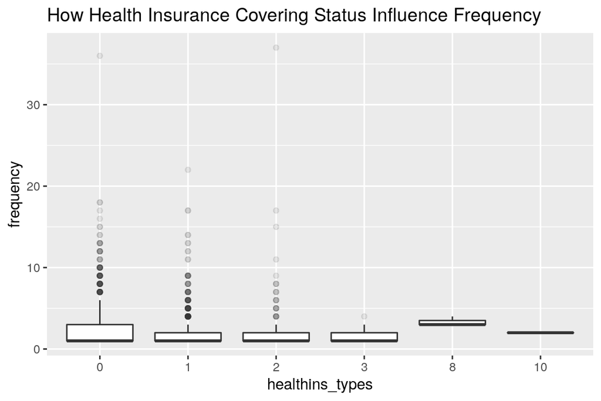

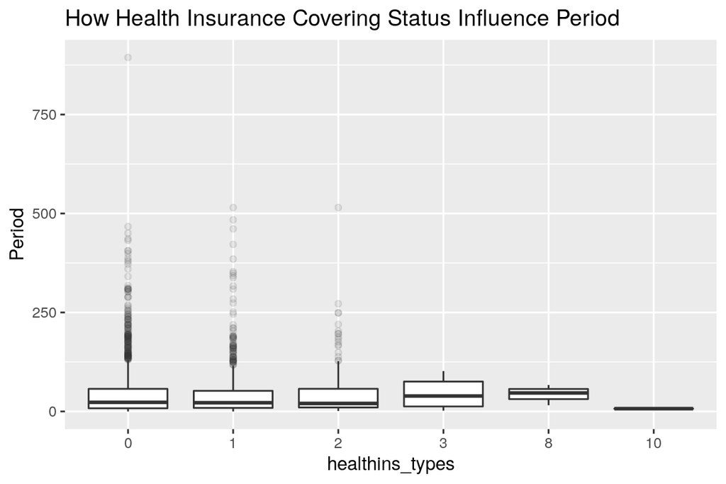

When wrangling the data, I found there is no change on health insurance between clients entry and exit. A large part of clients do not have health insurance (in 0 group) and they tend to come to UMD more frequently. But for period, there is few difference between each group.

##### (iii) Income v.s. Frequency/Period

In this part, I am going to deal with the relationship between clients income and the frenquency/period. There are two datasets about clients income: entry and exit. I found only a few part of them got changes on income so I am going to analyze with the exit income data and in next part I will seperately consider the changes of income.

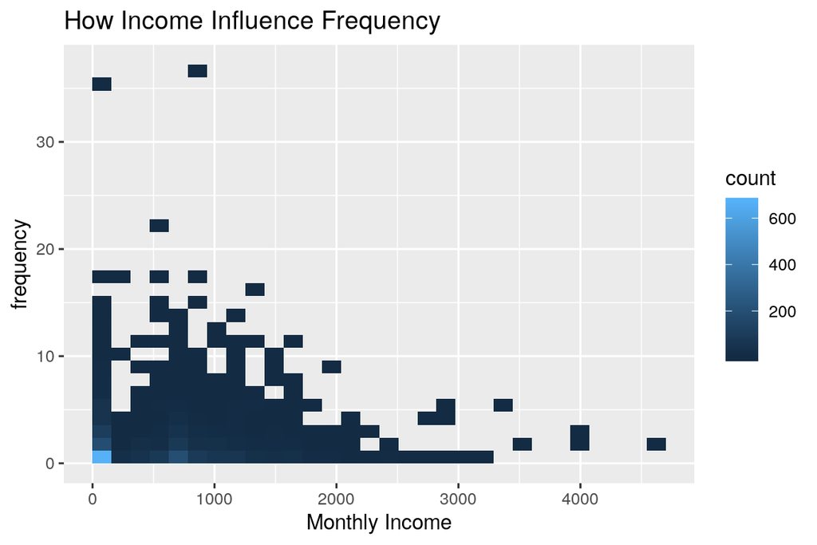

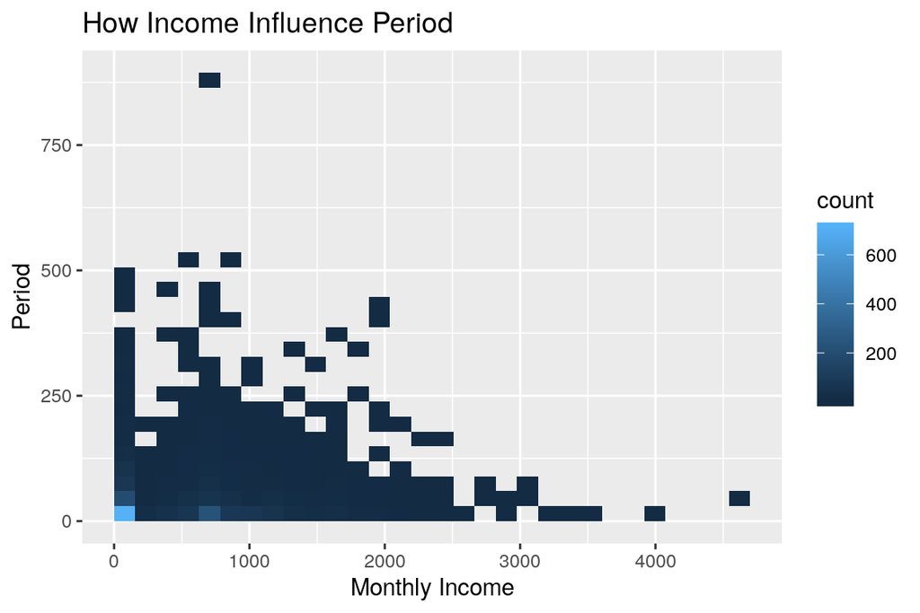

A large part of clients have no income, with NA or 0 in the dataset. Overall, clients with higher income are more likely to come UMD less frequently and stay for shorter time, which is compatible with our intuition.

##### (iv) Changes of Income (Entry and Exit) v.s. Frequency/Period

There are about 200 clients got changes of their income when entry UMD and exit. So I will figure out how the frequency and period correlated with their income changes.

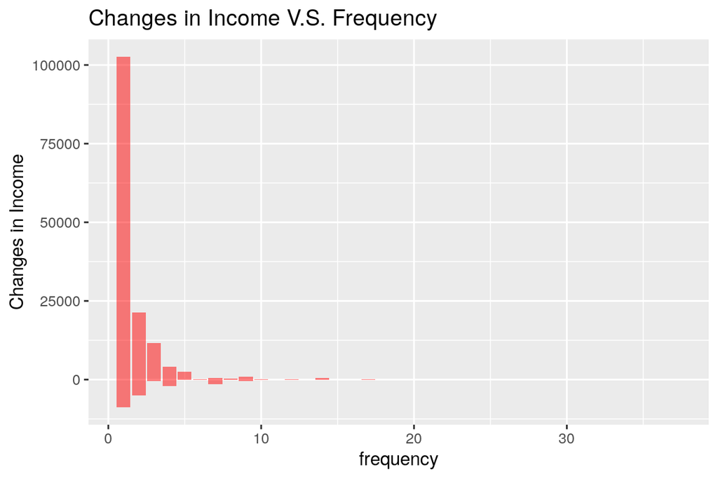

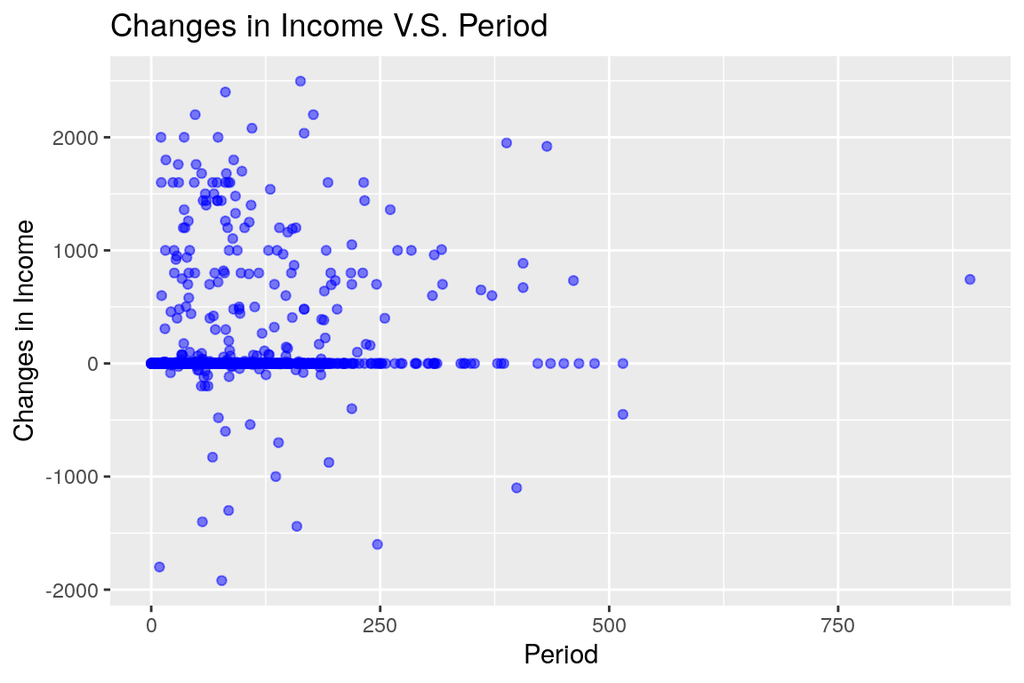

##### (v) Age at Entry v.s. Period

To figure out how long the clients at different age stay with UMD, I calculated the average of period of different entry age. Since lots of clients came to UMD for several times, this time I did not group the data by clients ID but by cases.

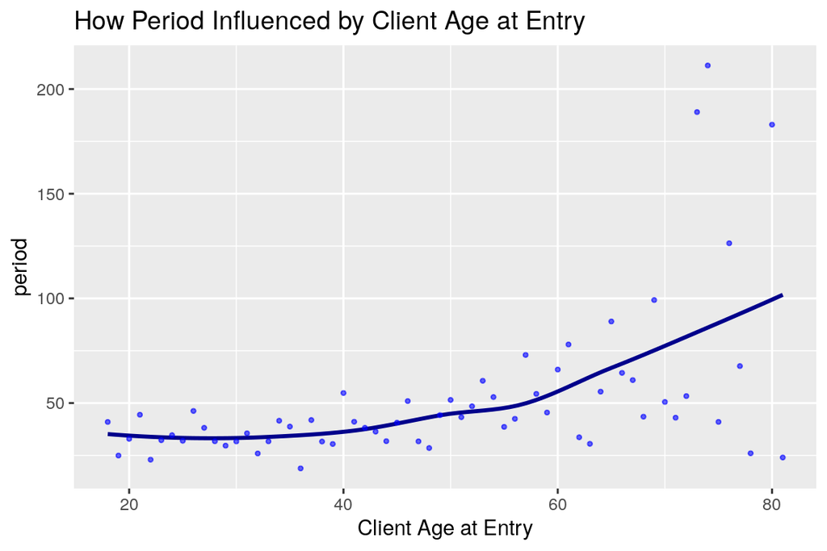

The overall trend shows that the elder when clients entry UMD, the longer they tend to stay.

By now we can summary some features of UMD potential clients: people with disabilities especially multiple types of disability (from 2 ~ 6); with no health insurance; no or low income (<1000 monthly) and continued for a period of time (get no changes for some time); with old age.

#### 2. What Happened Before the Clients Entry & After They Exit?

To answer this question, I am going to analyze the data of Destination After Exit and Homeless Status Before Entry so that I can further get the questions like who is more likely to come to UMD and how well the clients get helped from UMD or why they finally exit.

##### Homeless Status Before Entry

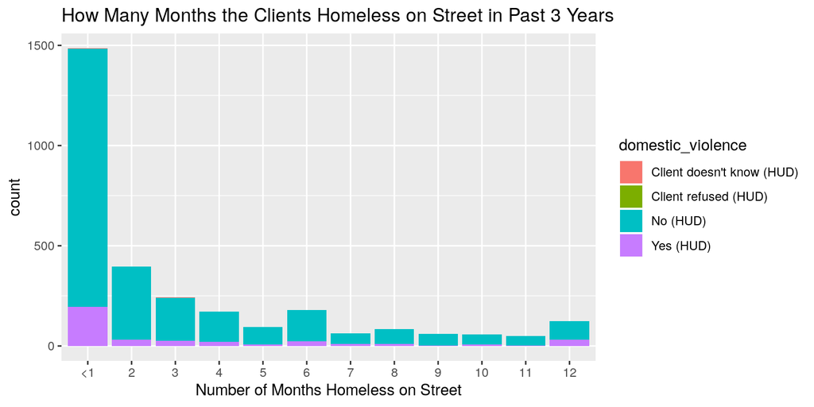

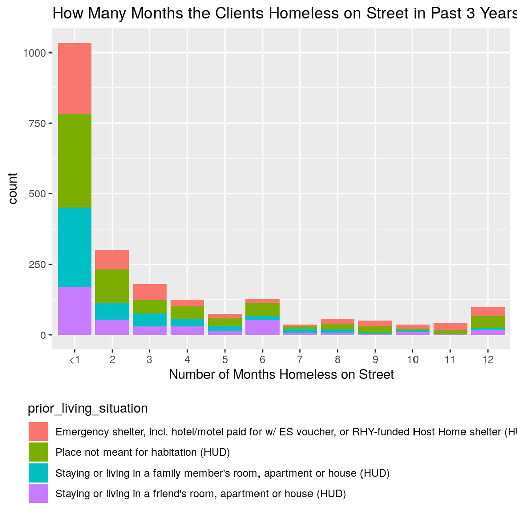

A large part of clients experience several-month-homeless before they came to UMD and a majority of them turn to UMD for help in the first month of homeless. I try to test my hypothesis that demostic violence may contribute to homeless to some degree.

The plot shows that proportion of homeless clients who suffered from domestic violence is higher than that proportion of the whole country (approximately 3%, comes from “National Statistics”. NCADV. National Coalition Against Domestic Violence. Retrieved 5 October 2018.) And for the prior living situation, the choice contribute the most is “place not meant for habitation”.

##### Destination After Exit

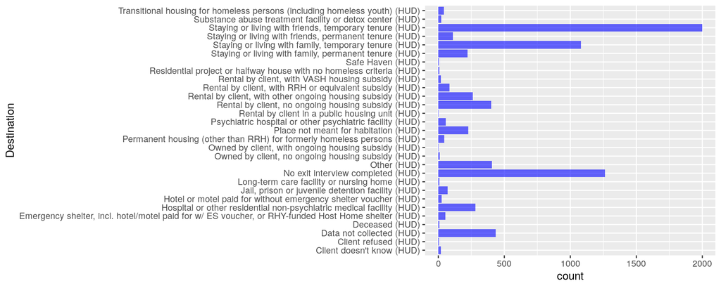

Top 3 meaningful destination: temporarily living with friends; temporarily living with family; rental by clients, no ongoing housing subsidy.

#### 3. How the Amount of Clients and Support Cases Change over Years

The dataset provide the information of clients and support cases from 2014-2019. In this part, I am going to show how the amount of clients and cases change over years.

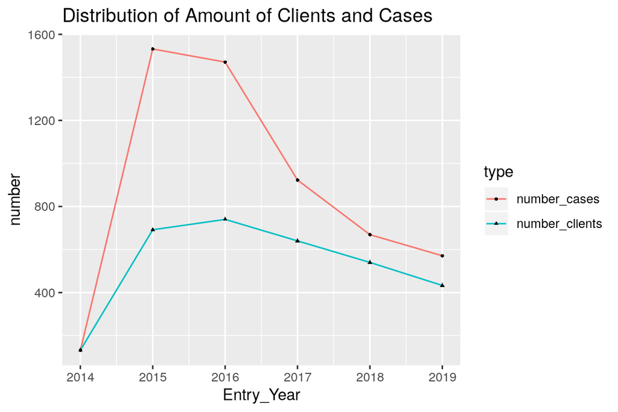

The plot shows that the trends of amount of clients and cases are similar: they increased dramatically from 2014~2015 and became smooth during 2015~2016, and in recent years decrease gradually. Since there are only data for 6 years, I am not going to do any prediction.